# Lin et al.: AAV Microglia

Label Transfer (Figure 2)

Ruiyu Ray Wang

2022-06-11

## TL;DR

You may click on the following links to fast forward to the codes directly producing the Figures:

- Figure 2a
- Figure 2b
- Figure 2c
- Figure 2d
- Figure 2e
- Figure 2f
- Figure 2g
- Figure 2h

Back to [index page](https://ruiyuraywang.github.io/Lin_AAV_Microglia_public/index.html).

## About this vignette

This vignette aims to reproduces Figure 2 in the original publication (Lin et al., 2022).

Here we only show how plain plots were generated directly from data. To reach the final illustrations in the publication, these plots may require further editing in graphic design softwares (i.e. Adobe Illustrator). Those beautification steps are not central to our analysis and therefore will be omitted.

## Initialization

```r
suppressPackageStartupMessages({
  library(Seurat)
  library(SeuratDisk)
  library(tidyverse)
  library(ggplot2)
  library(patchwork)
  library(RColorBrewer)
  library(cvms)
  library(epitools)
})
```

```r
querydata <- LoadH5Seurat('../data/AAV_MG_scRNAseq/query_clean.h5Seurat', verbose = F)
query_transferred <- LoadH5Seurat('../data/AAV_MG_scRNAseq/query_transferred.h5Seurat', verbose = F)
refdata <- LoadH5Seurat('../data/AAV_MG_scRNAseq/refdata_clean.h5Seurat', verbose = F)
refquery <- LoadH5Seurat('../data/AAV_MG_scRNAseq/refquery.h5Seurat', verbose = F)
```

## Reproducing Plots

### Figure 2a

Schematics showing the workflows of scRNAseq experiments and analysis.

```r
f2a1 <- DimPlot(querydata, pt.size = 2, group.by = "group", cols = brewer.pal(n = 12, name = "Paired")[c(7,6)]) +
  ggtitle(NULL) +
  theme_minimal() +
  theme(
    legend.position = "none",
    axis.title = element_blank(),
    axis.text = element_blank()
  )
```

```r
f2a2 <- DimPlot(refdata, group.by = "treat", pt.size = 2, shuffle = TRUE) +
  scale_color_manual(values = brewer.pal(n = 12, name = "Paired")[c(5,3,1)])+
  theme_minimal() +
  ggtitle(NULL) +
  theme(
    legend.position = "none",
    axis.title = element_blank(),
    axis.text = element_blank()
  )
```

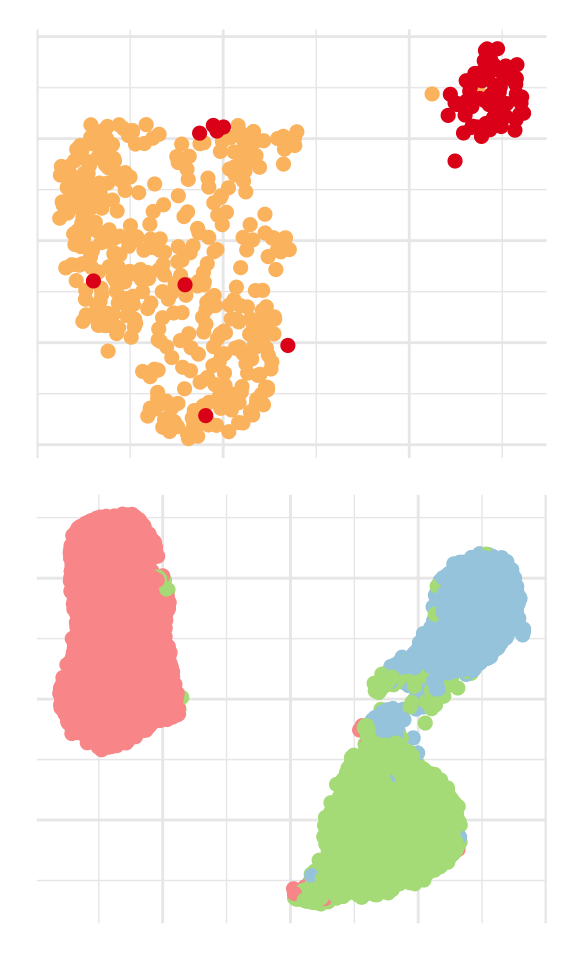

```r
f2a1 / f2a2
```

### Figure 2b-d

Descriptive analysis of the Query Dataset (Smart-seq2). Discrimination of “Transduced” and “Untransduced” cells are based on whether *mScarlet* transcripts are expressed in the cells (cell is “Transduced” if mScarlet > 0).

### Figure 2b

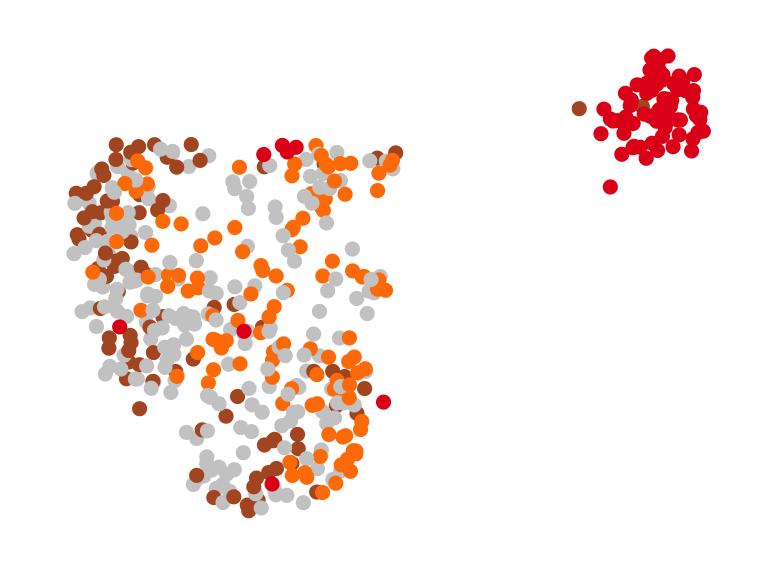

```r
DimPlot(querydata, group.by = "transduce_serotype", pt.size = 2,
        cols = c(brewer.pal(n = 12, name = "Paired")[c(12,8,6)],"#CCCCCC")) +
  NoAxes() +
  ggtitle(NULL) +
  theme(
    legend.position = "none",
    axis.title = element_blank(),
    axis.text = element_blank()
  )
```

### Figure 2c

```r
queryaav_sub <- subset(querydata, subset = group == "AAV")
queryaav_sub <- queryaav_sub %>%
  NormalizeData() %>%
  FindVariableFeatures() %>%
  ScaleData() %>%
  RunPCA() %>%
  FindNeighbors(dims = 1:20) %>%
  FindClusters(resolution = 0.3) %>%
  RunUMAP(dims = 1:20)
```

```
## Modularity Optimizer version 1.3.0 by Ludo Waltman and Nees Jan van Eck
##
## Number of nodes: 407
## Number of edges: 18673
##
## Running Louvain algorithm...
## Maximum modularity in 10 random starts: 0.7391
## Number of communities: 2
## Elapsed time: 0 seconds
```

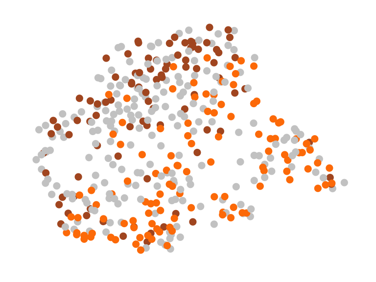

```r
DimPlot(queryaav_sub, group.by = "transduce_serotype", pt.size = 2,
        cols = c(brewer.pal(12, "Paired")[c(12,8)],"#CCCCCC")) +
  NoAxes() +
  ggtitle(NULL) +
  theme(
    legend.position = "none",
    axis.title = element_blank(),
    axis.text = element_blank()
  )
```

### Figure 2d

```r
## Order by factor
querydata$transduce_serotype <- factor(querydata$transduce_serotype,
                                       levels = c("LPS","AAV-MG1.1","AAV-MG1.2","Untransduced"))
umap_lps <- as.data.frame(Embeddings(querydata[["umap"]])) %>%
  mutate(transduce_serotype = querydata$transduce_serotype) %>%
  ggplot(mapping = aes(x = UMAP_1, y = UMAP_2, color = transduce_serotype)) +
  geom_point(aes(size = transduce_serotype), position = "jitter") +
  scale_size_manual(values = c(1.2,0.6,0.6,0.6)) +
  scale_color_manual(values = c(brewer.pal(12, "Paired")[c(6,11,7)],"#CCCCCC")) +
  theme(
    legend.position = "none",
    panel.background = element_blank(),
    panel.border = element_rect(color = "gray", size = 1, fill = NA),
    axis.title = element_blank(),
    axis.ticks = element_blank(),
    axis.text = element_blank(),
    legend.key = element_blank()
    )

queryaav_sub$transduce_serotype <- factor(queryaav_sub$transduce_serotype,
                                          levels = c("AAV-MG1.1","AAV-MG1.2","Untransduced"))
umap_mg1.1 <- as.data.frame(Embeddings(queryaav_sub[["umap"]])) %>%
  mutate(transduce_serotype = queryaav_sub$transduce_serotype) %>%
  ggplot(mapping = aes(x = UMAP_1, y = UMAP_2, color = transduce_serotype)) +
  geom_point(aes(size = transduce_serotype), position = "jitter") +
  scale_size_manual(values = c(1.2,0.6,0.6)) +
  scale_color_manual(values = c(brewer.pal(12, "Paired")[c(12,7)],"#CCCCCC")) +
  theme(
    legend.position = "none",
    panel.background = element_blank(),
    panel.border = element_rect(color = "gray", size = 1, fill = NA),
    axis.title = element_blank(),
    axis.ticks = element_blank(),
    axis.text = element_blank(),
    legend.key = element_blank()
    )

umap_mg1.2 <- as.data.frame(Embeddings(queryaav_sub[["umap"]])) %>%
  mutate(transduce_serotype = queryaav_sub$transduce_serotype) %>%
  ggplot(mapping = aes(x = UMAP_1, y = UMAP_2, color = transduce_serotype)) +
  geom_point(aes(size = transduce_serotype), position = "jitter") +
  scale_size_manual(values = c(0.6,1.2,0.6)) +
  scale_color_manual(values = c(brewer.pal(12, "Paired")[c(11,8)],"#CCCCCC")) +
  theme(
    legend.position = "none",
    panel.background = element_blank(),
    panel.border = element_rect(color = "gray", size = 1, fill = NA),
    axis.title = element_blank(),
    axis.ticks = element_blank(),
    axis.text = element_blank(),
    legend.key = element_blank()
    )

umap_non_transduced <- as.data.frame(Embeddings(queryaav_sub[["umap"]])) %>%
  mutate(transduce_serotype = queryaav_sub$transduce_serotype) %>%
  ggplot(mapping = aes(x = UMAP_1, y = UMAP_2, color = transduce_serotype)) +
  geom_point(aes(size = transduce_serotype), position = "jitter") +
  scale_size_manual(values = c(0.6,0.6,1.2)) +
  scale_color_manual(values = c(brewer.pal(12, "Paired")[c(11,7)],"#999999")) +
  theme(
    legend.position = "none",
    panel.background = element_blank(),
    panel.border = element_rect(color = "gray", size = 1, fill = NA),
    axis.title = element_blank(),
    axis.ticks = element_blank(),
    axis.text = element_blank(),
    legend.key = element_blank()
    )

querydata$transduce_serotype <- factor(querydata$transduce_serotype,
                                       levels = c("Untransduced","AAV-MG1.2","AAV-MG1.1","LPS"))
violin_mScarlet <- VlnPlot(querydata,
                           features = "mScarlet_norm",
                           group.by = "transduce_serotype",
                           cols = c("#CCCCCC",brewer.pal(12, "Paired")[c(7,11,5)]),
                           pt.size = 1) +
  coord_flip() +
  NoLegend() +
  ggtitle(NULL) +
  ylab("mScarlet Expression") +
  theme(
    legend.position = "none",
    axis.title.y = element_blank(),
    axis.text.y = element_blank(),
    axis.title.x = element_text(size = 18)
  )
```

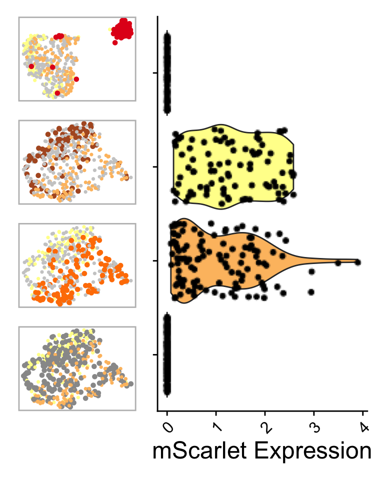

```r
((umap_lps / umap_mg1.1 / umap_mg1.2 / umap_non_transduced) | violin_mScarlet) + plot_layout(widths = c(0.9,1.6))
```

### Figure 2e

We notice that in the UMAP embedding showing the subset of microglia subjected to AAV delivery, the transduced and untransduced microglia are positioned in a “well-mixed” fashion, suggesting that the transduced microglia may share a similar transcriptional state with untransduced microglia.

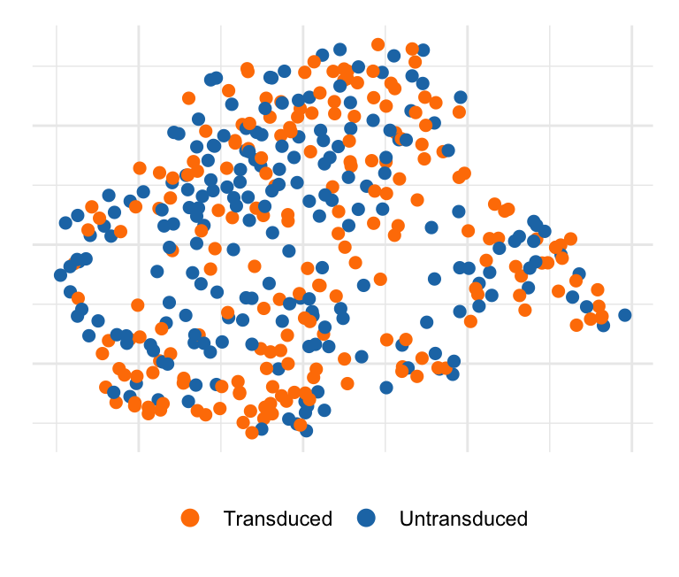

```r
DimPlot(queryaav_sub, group.by = "transduction",
        cols = brewer.pal(n = 12, name = "Paired")[c(8,2)],
        pt.size = 2) +
  NoAxes() +
  NoLegend() +
  theme_minimal() +
  ggtitle(NULL) +
  theme(
    panel.background = element_blank(),
    axis.title = element_blank(),
    axis.ticks = element_blank(),
    axis.text = element_blank(),
    legend.position = "bottom"
  )
```

To examine the relationship between transduction and transcriptional state in a more rigorous manner, we perform unsupervised clustering in the AAV delivery group using Louvain algorithm. Two cluster were obtained with distinct transcriptional states, as shown in the plots below.

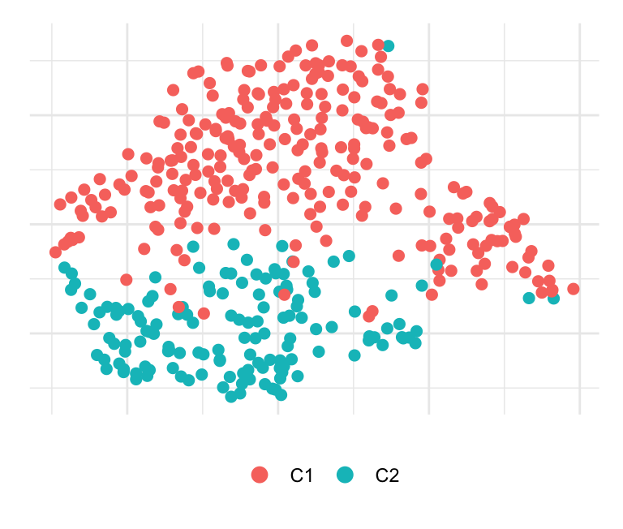

```r
Idents(queryaav_sub) <- "seurat_clusters"
queryaav_sub <- RenameIdents(queryaav_sub, `0` = "C1", `1` = "C2")
DimPlot(queryaav_sub, pt.size = 2) +
  NoAxes() +
  NoLegend() +
  theme_minimal() +
  ggtitle(NULL) +
  theme(
    panel.background = element_blank(),
    axis.title = element_blank(),
    axis.ticks = element_blank(),
    axis.text = element_blank(),
    legend.position = "bottom"
  )
```

### Figure 2f

Then, we collect the confusion matrix summarizing the microglia transduction state and Louvain cluster, and use `epitools` package to calculate the Odds Ratio (OR) from the confusion matrix. The Odds Ratio quantifies the association between two everts. In essence, an OR equal to 1 indicates that two events are independent. Here, we use `epitools` package to compute the OR, and test its value against 1 using “wald” method. The test result suggests that the OR does not deviate significantly from 1, suggesting that the trancriptional state and transduction state in microglia are independent.

Finally, we use `plot_confusion_matrix()` from the `cvms` package to visualize the confusion matrix.

```r
df <- queryaav_sub[[c("transduction","seurat_clusters")]]
df <- dplyr::rename(df, "Louvain clusters" = "seurat_clusters")

basic_table <- table(df)

epitools::oddsratio(basic_table, method = "wald")$measure[-1,]
```

```
##  estimate     lower     upper
## 0.7932876 0.5268557 1.1944544
```

```r
epitools::oddsratio(basic_table, method = "wald")$p.value
```

```
##               two-sided
## transduction   midp.exact fisher.exact chi.square
##   Transduced           NA           NA         NA
##   Untransduced  0.2696457    0.2978506  0.2670871
```

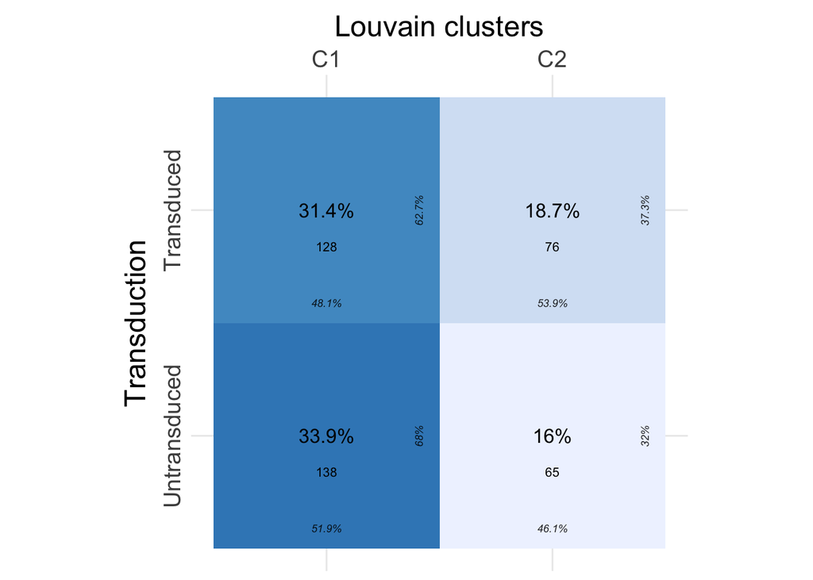

```r
## cvms::plot_confusion_matrix() use integer levels
df$transduction <- dplyr::recode(df$transduction, "Transduced" = 1, "Untransduced" = 0)

basic_table <- table(df)
cfm <- as_tibble(basic_table)

g <- cvms::plot_confusion_matrix(cfm,
                                 target_col = "Louvain clusters",
                                 prediction_col = "transduction",
                                 counts_col = "n",
                                 add_arrows = FALSE)
g +
  xlab("Louvain clusters") +
  ylab("Transduction") +
  scale_x_discrete(labels = c("C1","C2"), position = "top") +
  scale_y_discrete(labels = c("Untransduced","Transduced")) +
  theme(
    text = element_text(size = 18)
  )
```

### Figure 2g

Joint visualization by ‘De novo’ recomputed UMAP of query and reference datasets.

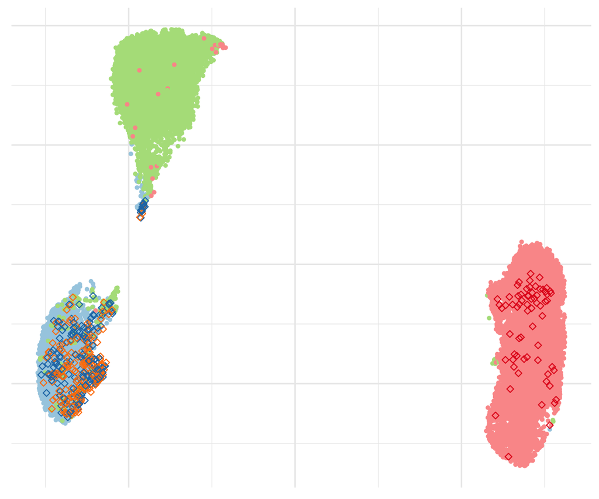

```r
as.data.frame(Embeddings(refquery[["umap"]])) %>%
  mutate(id = refquery$id, ident = refquery$ident) %>%
  ggplot(mapping = aes(x = UMAP_1, y = UMAP_2, color = ident, group = id)) +
  geom_point(aes(shape = id), size = 1.5) +
  scale_color_manual(values = brewer.pal(n = 12, name = "Paired")[c(5,6,3,1,8,2)]) +
  scale_shape_manual(values = c(20,23)) +
  theme_minimal() +
  theme(
    panel.background = element_blank(),
    axis.title = element_blank(),
    axis.ticks = element_blank(),
    axis.text = element_blank(),
    legend.position = "none"
    )
```

### Figure 2h

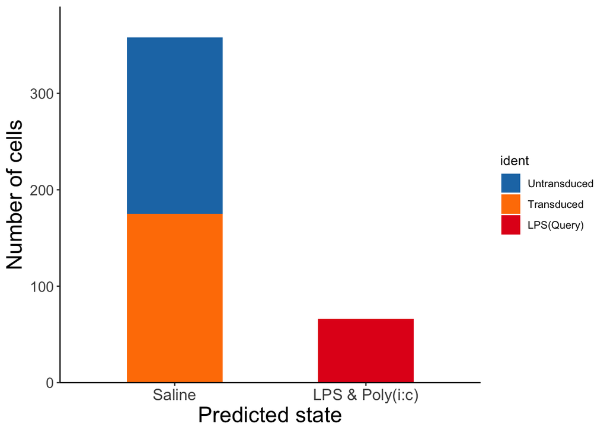

```r
query_transferred[[c("predicted.state","ident")]] %>%
  ggplot(mapping = aes(predicted.state)) +
  geom_bar(aes(fill = ident), width = 0.5) +
  scale_x_discrete(labels = c("Homeostatic" = "Saline", "Reactive" = "LPS & Poly(i:c)")) +
  scale_y_continuous(expand = c(0,0), limits = c(0,390)) +
  ylab("Number of cells") +
  xlab("Predicted state") +
  scale_fill_manual(values = brewer.pal(n = 12, name = "Paired")[c(2,8,6)]) +
  theme_classic() +
  theme(
    legend.position = "right",
    axis.title = element_text(size = 18),
    axis.text.y = element_text(size = 12),
    axis.text.x = element_text(size = 13),
  )
```